# data_science_project

## Unemployment Analysis & Prediction in India

### TEAM MEMBERS:

- ABHISHEK
- SATYAM
- VINAY
- DANISH
- ADITYA

Objective The main objective of this project is to analyze and predict unemployment trends in India using machine learning techniques. By studying state-wise and urban-rural data, we aim to identify the most affected regions, understand the impact of COVID-19, and highlight future unemployment risks. This project seeks to provide valuable insights for policymakers and organizations to design effective job creation and skill development strategies.

### Step 1: Load the Dataset

#### Task Performed by This Code

This block loads the **"Unemployment in India.csv"** dataset into a pandas DataFrame (`df`) for further analysis.

#### Why It Is Used

To perform any analysis or visualization in Python, we first need to **import the dataset** from an external source (like a CSV file). This code helps us bring the data into memory so we can clean, transform, and analyze it.

#### Theory Behind It

- **CSV (Comma-Separated Values)** is a common file format that stores tabular data in plain text.
- **Pandas** is a powerful Python library used for working with structured data.
- The function `pd.read_csv()` reads a CSV file and stores it in a DataFrame, which is similar to an Excel sheet in memory.

  **Real-life Analogy**:  
  Imagine you have a spreadsheet with unemployment data. This step is like opening that file in Excel so you can work with it — but here, you're doing it programmatically in Python.

#### Line-by-Line Explanation

```python import pandas as pd

```python
import pandas as pd

# Load the dataset
df = pd.read_csv("Unemployment in India.csv")
```

### Step 2: Preview the Dataset

#### Task Performed by This Code

This line displays the **first five rows** of the dataset using the `head()` function. It provides a quick look at the structure and content of the data.

#### Why It Is Used

After loading the dataset, it’s important to **verify** that it loaded correctly and to understand:

- What columns are present
- What types of data each column contains
- Whether there are any obvious issues (e.g., missing values, formatting problems)

This step helps you get a feel for the dataset before moving into cleaning or analysis.

#### Theory Behind It

- **DataFrame**: A table-like structure in Pandas.
- **`head()` function**: Returns the first 5 rows of the DataFrame by default.
- This is often used for **initial inspection** of the data right after loading it.

Real-life analogy:  
Just like flipping open the first page of a notebook to see what kind of entries it contains, `head()` gives you a peek at the beginning of your dataset.

#### Line-by-Line Explanation

```python df.head()

```python
df.head()
```

|  | Region | Date | Frequency | Estimated Unemployment Rate (%) | Estimated Employed | Estimated Labour Participation Rate (%) | Area |
| --- | --- | --- | --- | --- | --- | --- | --- |
| 0 | Andhra Pradesh | 31-05-2019 | Monthly | 3.65 | 11999139.0 | 43.24 | Rural |
| 1 | Andhra Pradesh | 30-06-2019 | Monthly | 3.05 | 11755881.0 | 42.05 | Rural |
| 2 | Andhra Pradesh | 31-07-2019 | Monthly | 3.75 | 12086707.0 | 43.50 | Rural |
| 3 | Andhra Pradesh | 31-08-2019 | Monthly | 3.32 | 12285693.0 | 43.97 | Rural |
| 4 | Andhra Pradesh | 30-09-2019 | Monthly | 5.17 | 12256762.0 | 44.68 | Rural |

# Analysis of Unemployment Data for Andhra Pradesh (Rural Area)

| Date | Estimated Unemployment Rate (%) | Estimated Employed | Labour Participation Rate (%) |
| --- | --- | --- | --- |
| 31-05-2019 | 3.65 | 11,999,139 | 43.24 |
| 30-06-2019 | 3.05 | 11,755,881 | 42.05 |
| 31-07-2019 | 3.75 | 12,086,707 | 43.50 |
| 31-08-2019 | 3.32 | 12,285,693 | 43.97 |
| 30-09-2019 | 5.17 | 12,256,762 | 44.68 |

### Key Insights:

- **Unemployment Rate Trends:**
  - The unemployment rate fluctuates monthly, remaining relatively low from May (3.65%) to August (3.32%), but sharply increases to 5.17% in September.
  - This spike in September suggests a sudden increase in joblessness despite prior stability.
- **Employment Numbers:**
  - The number of employed persons gradually rises from about 12 million in May to over 12.2 million in August and September.
  - The increase in employment alongside rising unemployment indicates more people are entering the labor force but not all are securing jobs.
- **Labour Participation Rate:**
  - The participation rate increases from 43.24% to 44.68%, showing more people are actively working or seeking work.
  - A rising participation rate coupled with rising unemployment suggests increased competition for jobs.

### Real-life Example:

Imagine a rural village where in May, 43 out of every 100 people are part of the workforce (working or job-seeking), and around 3-4 people can't find jobs. By September, more people (about 45 out of 100) start looking for work, but 5 out of those 100 remain unemployed. This indicates the local economy might be expanding, but job creation is not keeping pace with the growing labor force.

### Step 3: Inspect the Dataset Structure

#### Task Performed by This Code

This line prints a **summary of the dataset**, including the number of rows, columns, column names, non-null values, and data types.

#### Why It Is Used

Before cleaning or analyzing the data, we need to understand:

- What columns exist
- What types of data each column contains (e.g., integer, float, object/string)
- If there are **missing values** in any column

```python
df.info()
```

```
<class 'pandas.core.frame.DataFrame'>
RangeIndex: 768 entries, 0 to 767
Data columns (total 7 columns):
 #   Column                                    Non-Null Count  Dtype
---  ------                                    --------------  -----
 0   Region                                    740 non-null    object
 1    Date                                     740 non-null    object
 2    Frequency                                740 non-null    object
 3    Estimated Unemployment Rate (%)          740 non-null    float64
 4    Estimated Employed                       740 non-null    float64
 5    Estimated Labour Participation Rate (%)  740 non-null    float64
 6   Area                                      740 non-null    object
dtypes: float64(3), object(4)
memory usage: 42.1+ KB
```

# Dataframe Overview

- **Total rows:** 768
- **Total columns:** 7

| Column | Non-Null Count | Data Type |
| --- | --- | --- |
| Region | 740 | Object |
| Date | 740 | Object |
| Frequency | 740 | Object |
| Estimated Unemployment Rate (%) | 740 | Float64 |
| Estimated Employed | 740 | Float64 |
| Estimated Labour Participation Rate (%) | 740 | Float64 |
| Area | 740 | Object |

### Step 4: Clean Column Names (Remove Extra Spaces)

#### Task Performed by This Code

This line **removes any leading or trailing whitespace characters** from all column names in the dataset.

#### Why It Is Used

Sometimes, column names in CSV files can contain **extra spaces** at the beginning or end. These spaces may cause issues when:

- Accessing columns by name (`df['ColumnName']`)
- Matching columns during merges
- Writing clean, bug-free code

Removing these spaces ensures consistency and avoids errors caused by misnamed columns.

#### Theory Behind It

**What it does:**  
It removes extra spaces from the beginning and end of each column name in your DataFrame.

```python
df.columns = df.columns.str.strip()
```

### Step 5: Display the Full DataFrame

#### Task Performed by This Code

This line **outputs the entire dataset** stored in the DataFrame `df`. It allows you to visually inspect all rows and columns.

#### Why It Is Used

Displaying `df` helps verify:

- That the dataset is loaded correctly
- The actual values in all rows and columns
- Any visible data quality issues such as:
  - Wrong formats
  - Outliers
  - Inconsistencies
  - Missing values (if not already checked)

It is often used for **manual inspection** before applying any analysis or transformation.

#### Theory Behind It

- In Jupyter Notebook, simply typing the variable name (e.g., `df`) as the last line of a cell will **render the DataFrame in a nicely formatted table**.
- This is a built-in feature of Jupyter — it uses a rich display to show tabular data with scrolling and pagination (for large datasets).
- If the dataset is too large, only a few top and bottom rows are shown by default.

Real-life analogy:  
Just like opening the full sheet in Excel to scroll through the data and understand what's inside, writing `df` does the same in a notebook.

#### Line-by-Line Explanation

```python df

```python
df
```

|  | Region | Date | Frequency | Estimated Unemployment Rate (%) | Estimated Employed | Estimated Labour Participation Rate (%) | Area |
| --- | --- | --- | --- | --- | --- | --- | --- |
| 0 | Andhra Pradesh | 31-05-2019 | Monthly | 3.65 | 11999139.0 | 43.24 | Rural |
| 1 | Andhra Pradesh | 30-06-2019 | Monthly | 3.05 | 11755881.0 | 42.05 | Rural |
| 2 | Andhra Pradesh | 31-07-2019 | Monthly | 3.75 | 12086707.0 | 43.50 | Rural |
| 3 | Andhra Pradesh | 31-08-2019 | Monthly | 3.32 | 12285693.0 | 43.97 | Rural |
| 4 | Andhra Pradesh | 30-09-2019 | Monthly | 5.17 | 12256762.0 | 44.68 | Rural |
| ... | ... | ... | ... | ... | ... | ... | ... |
| 763 | NaN | NaN | NaN | NaN | NaN | NaN | NaN |
| 764 | NaN | NaN | NaN | NaN | NaN | NaN | NaN |
| 765 | NaN | NaN | NaN | NaN | NaN | NaN | NaN |
| 766 | NaN | NaN | NaN | NaN | NaN | NaN | NaN |
| 767 | NaN | NaN | NaN | NaN | NaN | NaN | NaN |

768 rows × 7 columns

# Monthly Employment Data Snapshot for Andhra Pradesh (Rural Area)

| Date | Estimated Unemployment Rate (%) | Estimated Employed | Labour Participation Rate (%) | Frequency | Area |
| --- | --- | --- | --- | --- | --- |
| 31-05-2019 | 3.65 | 11,999,139 | 43.24 | Monthly | Rural |
| 30-06-2019 | 3.05 | 11,755,881 | 42.05 | Monthly | Rural |
| 31-07-2019 | 3.75 | 12,086,707 | 43.50 | Monthly | Rural |
| 31-08-2019 | 3.32 | 12,285,693 | 43.97 | Monthly | Rural |
| 30-09-2019 | 5.17 | 12,256,762 | 44.68 | Monthly | Rural |
| 31-10-2019 | 3.52 | 12,017,412 | 43.01 | Monthly | Rural |
| 30-11-2019 | 4.12 | 11,397,681 | — | Monthly | Rural |
| 31-12-2019 | 4.38 | 12,528,395 | 41.00 | Monthly | Rural |
| 31-01-2020 | 4.84 | 12,016,676 | 45.14 | Monthly | Rural |
| 29-02-2020 | 5.91 | 11,723,617 | 43.46 | Monthly | Rural |

### Key Insights:

This summary provides an overview of monthly employment trends for rural Andhra Pradesh from May 2019 to February 2020.

### Step 6: Remove Missing Values

#### Task Performed by This Code

This line removes **all rows that contain missing (NaN) values** from the DataFrame `df`.

#### Why It Is Used

In real-world datasets, it is common to find missing or incomplete data. These missing values can:

- Affect the accuracy of analysis and visualizations
- Break statistical or machine learning models
- Cause errors in calculations

By dropping rows with missing values, we ensure that only **complete and clean records** are retained for further analysis.

#### Theory Behind It

- **Missing data (NaN)** stands for "Not a Number" and represents empty or undefined values in a DataFrame.
- **`dropna()`** is a pandas method used to remove rows (or columns) with any missing values.
- **`inplace=True`** applies the change directly to the existing DataFrame without creating a copy.

Real-life example:  
Imagine a survey form where some people skipped a question. You might choose to ignore those incomplete forms if the missing question is essential to your analysis.

#### Line-by-Line Explanation

```python df.dropna(inplace=True)

```python
df.dropna(inplace=True)
```

### Step 7: Display Cleaned DataFrame

#### Task Performed by This Code

This line simply displays the updated DataFrame `df` after rows with missing values have been removed.

#### Why It Is Used

After performing data cleaning (like dropping missing values), it's important to:

- Visually confirm that the cleaning worked
- Ensure the structure and values are still intact
- See how many rows remain after removing incomplete records

#### Theory Behind It

- When you type a variable like `df` in a Jupyter Notebook cell, it automatically **renders the DataFrame as a formatted table**.
- This is a quick way to manually inspect changes made by previous operations such as filtering, cleaning, or transformations.

```python
df
```

|  | Region | Date | Frequency | Estimated Unemployment Rate (%) | Estimated Employed | Estimated Labour Participation Rate (%) | Area |
| --- | --- | --- | --- | --- | --- | --- | --- |
| 0 | Andhra Pradesh | 31-05-2019 | Monthly | 3.65 | 11999139.0 | 43.24 | Rural |
| 1 | Andhra Pradesh | 30-06-2019 | Monthly | 3.05 | 11755881.0 | 42.05 | Rural |
| 2 | Andhra Pradesh | 31-07-2019 | Monthly | 3.75 | 12086707.0 | 43.50 | Rural |
| 3 | Andhra Pradesh | 31-08-2019 | Monthly | 3.32 | 12285693.0 | 43.97 | Rural |
| 4 | Andhra Pradesh | 30-09-2019 | Monthly | 5.17 | 12256762.0 | 44.68 | Rural |
| ... | ... | ... | ... | ... | ... | ... | ... |
| 749 | West Bengal | 29-02-2020 | Monthly | 7.55 | 10871168.0 | 44.09 | Urban |
| 750 | West Bengal | 31-03-2020 | Monthly | 6.67 | 10806105.0 | 43.34 | Urban |
| 751 | West Bengal | 30-04-2020 | Monthly | 15.63 | 9299466.0 | 41.20 | Urban |
| 752 | West Bengal | 31-05-2020 | Monthly | 15.22 | 9240903.0 | 40.67 | Urban |
| 753 | West Bengal | 30-06-2020 | Monthly | 9.86 | 9088931.0 | 37.57 | Urban |

740 rows × 7 columns

### Step 8: Check for Missing Values in Each Column

#### Task Performed by This Code

This line checks for **missing (NaN)** values in each column of the DataFrame and returns the **total count per column**.

#### Why It Is Used

After loading or modifying data, it's essential to verify:

- Whether any columns still contain missing values
- How many values are missing per column
- If further cleaning (e.g., filling or dropping) is required

This step helps in deciding how to handle incomplete data.

#### Theory Behind It

```python
df.isnull().sum()
```

```
Region                                     0
Date                                       0
Frequency                                  0
Estimated Unemployment Rate (%)            0
Estimated Employed                         0
Estimated Labour Participation Rate (%)    0
Area                                       0
dtype: int64
```

### Step 9: Clean and Prepare Dataset for Analysis

This code block performs **data cleaning and feature engineering** to make the dataset analysis-ready. Below is a detailed explanation of each step.

#### Task Performed

- Standardizes column names and values
- Removes missing data
- Converts date strings into actual date objects
- Creates new columns: `Year` and `Month` for time-based analysis

#### Why It Is Used

```python
# Clean column names
df.columns = df.columns.str.strip()

# Drop missing rows
df.dropna(inplace=True)

# Remove leading/trailing spaces from all string-type columns
df = df.apply(lambda x: x.str.strip() if x.dtype == "object" else x)

# Convert Date column to datetime
df['Date'] = pd.to_datetime(df['Date'], format="%d-%m-%Y")

# Add Year and Month columns
df['Year'] = df['Date'].dt.year
df['Month'] = df['Date'].dt.month
```

### Step 10: Display Final Cleaned DataFrame

#### Task Performed by This Code

This line displays the **current state of the DataFrame `df`** after all the preprocessing steps like cleaning, transforming, and feature engineering.

#### Why It Is Used

After performing data preparation tasks, it is important to:

- Visually confirm that changes were applied correctly
- Check the newly added columns (`Year`, `Month`)
- Ensure there are no missing or incorrectly formatted values

#### Theory Behind It

- Typing `df` in a Jupyter Notebook cell automatically **renders the DataFrame** in a tabular format.
- It provides a complete view of:
  - Column names
  - Data types
  - Actual data values
  - Newly created features (like `Year` and `Month`)

> Real-life analogy: Like viewing a cleaned and sorted Excel sheet after organizing and reformatting the raw data.

#### Line-by-Line Explanation

```python df

```python
df
```

|  | Region | Date | Frequency | Estimated Unemployment Rate (%) | Estimated Employed | Estimated Labour Participation Rate (%) | Area | Year | Month |
| --- | --- | --- | --- | --- | --- | --- | --- | --- | --- |
| 0 | Andhra Pradesh | 2019-05-31 | Monthly | 3.65 | 11999139.0 | 43.24 | Rural | 2019 | 5 |
| 1 | Andhra Pradesh | 2019-06-30 | Monthly | 3.05 | 11755881.0 | 42.05 | Rural | 2019 | 6 |
| 2 | Andhra Pradesh | 2019-07-31 | Monthly | 3.75 | 12086707.0 | 43.50 | Rural | 2019 | 7 |
| 3 | Andhra Pradesh | 2019-08-31 | Monthly | 3.32 | 12285693.0 | 43.97 | Rural | 2019 | 8 |
| 4 | Andhra Pradesh | 2019-09-30 | Monthly | 5.17 | 12256762.0 | 44.68 | Rural | 2019 | 9 |
| ... | ... | ... | ... | ... | ... | ... | ... | ... | ... |
| 749 | West Bengal | 2020-02-29 | Monthly | 7.55 | 10871168.0 | 44.09 | Urban | 2020 | 2 |
| 750 | West Bengal | 2020-03-31 | Monthly | 6.67 | 10806105.0 | 43.34 | Urban | 2020 | 3 |
| 751 | West Bengal | 2020-04-30 | Monthly | 15.63 | 9299466.0 | 41.20 | Urban | 2020 | 4 |
| 752 | West Bengal | 2020-05-31 | Monthly | 15.22 | 9240903.0 | 40.67 | Urban | 2020 | 5 |
| 753 | West Bengal | 2020-06-30 | Monthly | 9.86 | 9088931.0 | 37.57 | Urban | 2020 | 6 |

740 rows × 9 columns

### Step 11: Convert Full DateTime to Only Date

#### Task Performed by This Code

This line **removes the time portion** from the `'Date'` column, leaving only the date (year, month, and day) as a plain date object.

#### Why It Is Used

- By default, pandas stores dates as **datetime objects**, which include time (e.g., `2019-05-31 00:00:00`)
- If your dataset doesn't require time details (like hours or seconds), keeping only the **date part** makes it cleaner and more readable
- Especially useful when displaying data, exporting reports, or grouping by date

#### Theory Behind It

- `df['Date']` is currently in `datetime64[ns]` format, which includes both date and time.
- `.dt.date` extracts only the **date portion** as a `datetime.date` object.
- This removes the `"00:00:00"` part that comes by default with datetime values.

> Real-life analogy: Like keeping only the "31 May 2019" part of a calendar entry instead of including "12:00 AM".

#### Line-by-Line Explanation

```python df['Date'] = df['Date'].dt.date

```python
# Convert full datetime to only date
df['Date'] = df['Date'].dt.date
```

### Step 12: Display DataFrame After Simplifying Date Format

#### Task Performed by This Code

This displays the updated DataFrame `df` where the `'Date'` column now contains **only the date** (without time).

#### Why It Is Used

After modifying the `'Date'` column, it's helpful to:

- Visually confirm the format has been simplified
- Check if the conversion was successful
- Ensure data still aligns correctly with other columns like `Year` and `Month`

#### Theory Behind It

- In Jupyter Notebook, entering `df` will output the current state of the DataFrame.
- This is a fast way to manually verify changes without writing additional code.

```python
df
```

|  | Region | Date | Frequency | Estimated Unemployment Rate (%) | Estimated Employed | Estimated Labour Participation Rate (%) | Area | Year | Month |
| --- | --- | --- | --- | --- | --- | --- | --- | --- | --- |
| 0 | Andhra Pradesh | 2019-05-31 | Monthly | 3.65 | 11999139.0 | 43.24 | Rural | 2019 | 5 |
| 1 | Andhra Pradesh | 2019-06-30 | Monthly | 3.05 | 11755881.0 | 42.05 | Rural | 2019 | 6 |
| 2 | Andhra Pradesh | 2019-07-31 | Monthly | 3.75 | 12086707.0 | 43.50 | Rural | 2019 | 7 |
| 3 | Andhra Pradesh | 2019-08-31 | Monthly | 3.32 | 12285693.0 | 43.97 | Rural | 2019 | 8 |
| 4 | Andhra Pradesh | 2019-09-30 | Monthly | 5.17 | 12256762.0 | 44.68 | Rural | 2019 | 9 |
| ... | ... | ... | ... | ... | ... | ... | ... | ... | ... |
| 749 | West Bengal | 2020-02-29 | Monthly | 7.55 | 10871168.0 | 44.09 | Urban | 2020 | 2 |
| 750 | West Bengal | 2020-03-31 | Monthly | 6.67 | 10806105.0 | 43.34 | Urban | 2020 | 3 |
| 751 | West Bengal | 2020-04-30 | Monthly | 15.63 | 9299466.0 | 41.20 | Urban | 2020 | 4 |
| 752 | West Bengal | 2020-05-31 | Monthly | 15.22 | 9240903.0 | 40.67 | Urban | 2020 | 5 |
| 753 | West Bengal | 2020-06-30 | Monthly | 9.86 | 9088931.0 | 37.57 | Urban | 2020 | 6 |

740 rows × 9 columns

### Step 13: Check for Missing Values in Specific Columns

#### Task Performed by This Code

This line checks whether there are **any missing values** in the columns:

- `'Estimated Employed'`
- `'Estimated Labour Participation Rate (%)'`

It returns the **number of missing values** in each of those two columns.

#### Why It Is Used

These two fields are critical for any employment analysis, so we want to:

- Ensure they contain complete data
- Detect any gaps before performing calculations or visualizations

#### Theory Behind It

- `.isnull()` creates a DataFrame of `True/False` values for missing data
- `.sum()` adds up the `True` values (each `True` counts as 1 missing value)
- When applied to selected columns, it provides a **focused quality check**

> Real-life analogy: Like checking if two important survey questions were skipped by any respondent — and counting how many times that happened.

#### Line-by-Line Explanation

```python df[['Estimated Employed', 'Estimated Labour Participation Rate (%)']].isnull().sum()

```python
df[['Estimated Employed', 'Estimated Labour Participation Rate (%)']].isnull().sum()
```

```
Estimated Employed                         0
Estimated Labour Participation Rate (%)    0
dtype: int64
```

### Step 14: Define a Function to Remove Outliers Using IQR Method

#### Task Performed by This Code

This function removes **outlier values** from a specified column of a DataFrame using the **Interquartile Range (IQR) method**.

#### Why It Is Used

- Outliers can skew your analysis, visualizations, and model performance.
- Removing outliers helps in producing more **reliable statistical results** and clearer **trend patterns**.

#### Theory: Interquartile Range (IQR) Method

The IQR method is a standard way to detect and remove outliers based on distribution:

- **Q1 (25th percentile)**: Value below which 25% of the data lies
- **Q3 (75th percentile)**: Value below which 75% of the data lies
- **IQR** = Q3 - Q1

Outliers are typically defined as:

- **Too low**: values less than Q1 - 1.5 × IQR
- **Too high**: values greater than Q3 + 1.5 × IQR

> Real-life analogy: Imagine filtering out abnormally high or low exam scores that happened due to cheating or technical issues.

#### Line-by-Line Explanation

```python def remove_outliers_iqr(df, column):

```python
def remove_outliers_iqr(df, column):
    Q1 = df[column].quantile(0.25)  # 25th percentile
    Q3 = df[column].quantile(0.75)  # 75th percentile
    IQR = Q3 - Q1
    lower = Q1 - 1.5 * IQR
    upper = Q3 + 1.5 * IQR
    return df[(df[column] >= lower) & (df[column] <= upper)]
```

### Step 15: Remove Outliers from Important Numeric Columns

#### Task Performed by This Code

These two lines apply the `remove_outliers_iqr()` function to remove outliers from:

1. `'Estimated Employed'`
2. `'Estimated Labour Participation Rate (%)'`

The cleaned data replaces the original DataFrame `df`.

#### Why It Is Used

- To **improve data quality** by removing extremely high or low values that may be due to errors or rare anomalies
- Ensures that plots, statistics, and models are not influenced by such extreme points
- Focuses analysis on the **typical (central) behavior**

```python
df = remove_outliers_iqr(df, 'Estimated Employed')
df = remove_outliers_iqr(df, 'Estimated Labour Participation Rate (%)')
```

### Step 16: Check the Shape of the Cleaned Dataset

#### Task Performed by This Code

This line displays the **dimensions (rows and columns)** of the current DataFrame after cleaning.

#### Why It Is Used

- To check how much data remains after outlier removal
- Useful to understand the **impact** of preprocessing steps (e.g., removing nulls and outliers)
- Helps track data reduction and ensure there's still enough data for analysis

#### Theory Behind It

- Every DataFrame has a `.shape` attribute
- It returns a tuple in the format:  
  `(number of rows, number of columns)`

> Real-life analogy: Like checking how many records are left in a cleaned Excel sheet after deleting invalid entries.

#### Line-by-Line Explanation

```python df.shape

```python
df.shape
```

```
(662, 9)
```

### Step 17: Display Final Cleaned DataFrame

#### Task Performed by This Code

This command displays the current contents of the DataFrame `df`, after:

- Removing missing values
- Stripping extra spaces
- Converting the `Date` column
- Adding `Year` and `Month`
- Removing outliers from key numeric columns

#### Why It Is Used

- To **visually verify** the cleaned dataset
- Confirm all preprocessing steps have been applied correctly
- Get a sense of what the final working data looks like before analysis or visualization

#### Theory Behind It

```python
df
```

|  | Region | Date | Frequency | Estimated Unemployment Rate (%) | Estimated Employed | Estimated Labour Participation Rate (%) | Area | Year | Month |
| --- | --- | --- | --- | --- | --- | --- | --- | --- | --- |
| 0 | Andhra Pradesh | 2019-05-31 | Monthly | 3.65 | 11999139.0 | 43.24 | Rural | 2019 | 5 |
| 1 | Andhra Pradesh | 2019-06-30 | Monthly | 3.05 | 11755881.0 | 42.05 | Rural | 2019 | 6 |
| 2 | Andhra Pradesh | 2019-07-31 | Monthly | 3.75 | 12086707.0 | 43.50 | Rural | 2019 | 7 |
| 3 | Andhra Pradesh | 2019-08-31 | Monthly | 3.32 | 12285693.0 | 43.97 | Rural | 2019 | 8 |
| 4 | Andhra Pradesh | 2019-09-30 | Monthly | 5.17 | 12256762.0 | 44.68 | Rural | 2019 | 9 |
| ... | ... | ... | ... | ... | ... | ... | ... | ... | ... |
| 749 | West Bengal | 2020-02-29 | Monthly | 7.55 | 10871168.0 | 44.09 | Urban | 2020 | 2 |
| 750 | West Bengal | 2020-03-31 | Monthly | 6.67 | 10806105.0 | 43.34 | Urban | 2020 | 3 |
| 751 | West Bengal | 2020-04-30 | Monthly | 15.63 | 9299466.0 | 41.20 | Urban | 2020 | 4 |
| 752 | West Bengal | 2020-05-31 | Monthly | 15.22 | 9240903.0 | 40.67 | Urban | 2020 | 5 |
| 753 | West Bengal | 2020-06-30 | Monthly | 9.86 | 9088931.0 | 37.57 | Urban | 2020 | 6 |

662 rows × 9 columns

### Step 18: Calculate Unemployment Rate (If Missing)

#### Task Performed by This Code

This block checks if the column `'Estimated Unemployment Rate (%)'` is missing from the DataFrame.  
If it's missing, it calculates and adds it.  
If it already exists, it skips recalculation.

#### Why It Is Used

- To **ensure consistency** in the dataset
- Avoids recalculating an existing column (which may already be correct or cleaned)
- Automates filling a **crucial economic indicator** if it's missing

#### Theory Behind the Calculation

The formula used is:

```python
if 'Estimated Unemployment Rate (%)' not in df.columns:
    df['Estimated Unemployment Rate (%)'] = 100 - (df['Estimated Employed'] * 100 / df['Estimated Labour Participation Rate (%)'])
else:
    print("Unemployment Rate already exists in the dataset.")
```

```
Unemployment Rate already exists in the dataset.
```

### Step 19: Create a Pivot Table for Rural vs. Urban Unemployment Rate

#### Task Performed by This Code

This code creates a **pivot table** that reorganizes the dataset to compare the **unemployment rate** across **Rural** and **Urban** areas, for each **Region and Date**.

#### Why It Is Used

- To simplify **side-by-side comparison** between rural and urban unemployment
- Converts long-format data into a **wide format** (which is easier for analysis and plotting)
- Prepares the data for calculating gaps or visualizing trends across geography and time

#### Theory Behind Pivot Tables

A **pivot table** in pandas:

- Summarizes data based on combinations of selected columns
- Converts rows into columns (and vice versa)
- Aggregates values (e.g., using `mean`, `sum`, etc.)

> Real-life analogy: Like transforming a long grocery bill into a neat table comparing prices of fruits vs vegetables by store and date.

#### Line-by-Line Explanation

```python pivot_area = df.pivot_table(

```python
pivot_area = df.pivot_table(
    index=['Region', 'Date'],
    columns='Area',
    values='Estimated Unemployment Rate (%)'
).reset_index()
```

### Step 20: Calculate Rural–Urban Unemployment Rate Gap

#### Task Performed by This Code

This line adds a new column `'Rural-Urban Gap (%)'` to the `pivot_area` DataFrame.  
It calculates the **difference in unemployment rates** between **Urban and Rural** areas for each region and date.

#### Why It Is Used

- To measure the **inequality in employment conditions** between urban and rural areas
- Helps in:
  - Identifying areas where unemployment is higher in urban or rural settings
  - Understanding regional disparities
  - Making data-driven policy suggestions

#### Theory Behind the Calculation

The formula used is:

[ \text{Rural-Urban Gap (\%)} = \text{Urban Rate} - \text{Rural Rate} ]

Interpretation:

- **Positive value** → Urban unemployment is higher than rural
- **Negative value** → Rural unemployment is higher than urban
- **Zero** → Both have equal unemployment rates

> Real-life analogy: Like comparing test scores of two students to see who is lagging — the gap gives a clear picture.

#### Line-by-Line Explanation

```python pivot_area['Rural-Urban Gap (%)'] = pivot_area['Urban'] - pivot_area['Rural']

```python
pivot_area['Rural-Urban Gap (%)'] = pivot_area['Urban'] - pivot_area['Rural']
```

### Step 21: Merge Rural–Urban Gap Back into Main Dataset

#### Task Performed by This Code

This line **joins** the calculated `'Rural-Urban Gap (%)'` column from the `pivot_area` table back into the original `df` DataFrame, so that the gap is available in the full dataset for every row.

#### Why It Is Used

- To **enrich** the main dataset with the new rural–urban gap feature
- So that every individual record (row) now has access to the **region's unemployment gap** for its date
- Useful for further analysis, visualization, or modeling

#### Theory Behind It

This is a **left merge** (also called a left join), which works like this:

- It matches each row in `df` with rows in `pivot_area` based on matching `'Region'` and `'Date'`
- Adds the `'Rural-Urban Gap (%)'` column where a match is found
- Keeps all rows from the **left** DataFrame (`df`), even if no match is found

> Real-life analogy: Like taking a student list and adding their class average from a separate summary table, matched by student name and date.

#### Line-by-Line Explanation

```python df = pd.merge(

```python
df = pd.merge(df, pivot_area[['Region', 'Date', 'Rural-Urban Gap (%)']], on=['Region', 'Date'], how='left')
```

### Step 22: Display Final Enriched DataFrame

#### Task Performed by This Code

This line simply outputs the **final version** of the `df` DataFrame after:

- Cleaning
- Feature extraction
- Outlier removal
- Pivoting
- Merging the calculated rural–urban gap

#### Why It Is Used

- To **verify** that the new `'Rural-Urban Gap (%)'` column has been successfully added
- To inspect whether the merge operation worked as expected
- To view the structure and content of the fully prepared dataset before analysis

#### Theory Behind It

- When you type the name of a DataFrame in a code cell in Jupyter Notebook, it **prints a preview** of the data
- This helps with:
  - Manual inspection of column values
  - Checking for missing or unexpected values
  - Ensuring all preprocessing steps were applied correctly

> Real-life analogy: Like looking at the final filled Excel sheet after applying formulas and adding calculated columns.

#### Line-by-Line Explanation

```python df

```python
df
```

|  | Region | Date | Frequency | Estimated Unemployment Rate (%) | Estimated Employed | Estimated Labour Participation Rate (%) | Area | Year | Month | Rural-Urban Gap (%) |
| --- | --- | --- | --- | --- | --- | --- | --- | --- | --- | --- |
| 0 | Andhra Pradesh | 2019-05-31 | Monthly | 3.65 | 11999139.0 | 43.24 | Rural | 2019 | 5 | 2.44 |
| 1 | Andhra Pradesh | 2019-06-30 | Monthly | 3.05 | 11755881.0 | 42.05 | Rural | 2019 | 6 | 0.75 |
| 2 | Andhra Pradesh | 2019-07-31 | Monthly | 3.75 | 12086707.0 | 43.50 | Rural | 2019 | 7 | 1.89 |
| 3 | Andhra Pradesh | 2019-08-31 | Monthly | 3.32 | 12285693.0 | 43.97 | Rural | 2019 | 8 | 1.29 |
| 4 | Andhra Pradesh | 2019-09-30 | Monthly | 5.17 | 12256762.0 | 44.68 | Rural | 2019 | 9 | 0.84 |
| ... | ... | ... | ... | ... | ... | ... | ... | ... | ... | ... |
| 657 | West Bengal | 2020-02-29 | Monthly | 7.55 | 10871168.0 | 44.09 | Urban | 2020 | 2 | 3.77 |
| 658 | West Bengal | 2020-03-31 | Monthly | 6.67 | 10806105.0 | 43.34 | Urban | 2020 | 3 | -0.35 |
| 659 | West Bengal | 2020-04-30 | Monthly | 15.63 | 9299466.0 | 41.20 | Urban | 2020 | 4 | -2.69 |
| 660 | West Bengal | 2020-05-31 | Monthly | 15.22 | 9240903.0 | 40.67 | Urban | 2020 | 5 | -3.21 |
| 661 | West Bengal | 2020-06-30 | Monthly | 9.86 | 9088931.0 | 37.57 | Urban | 2020 | 6 | 4.92 |

662 rows × 10 columns

### Step 23: Sort the DataFrame by Region, Area, and Date

#### Task Performed by This Code

This line rearranges the rows of the DataFrame `df` in a logical order — first by `Region`, then by `Area` (Rural/Urban), and then by `Date`.

#### Why It Is Used

- To make the dataset more **organized** and **readable**
- Ensures that all records for the same region and area are grouped together and appear in **chronological order**
- Essential for:
  - Time series analysis
  - Generating accurate visualizations
  - Calculating trends like month-over-month change

> Without sorting, you might mistakenly compare unrelated time periods or mixed-up regions.

#### Theory Behind Sorting in Data Analysis

Sorting is often the **first step** before doing any:

- Moving averages
- Trend analysis
- Group-based aggregations
- Plotting clean time series graphs

> Real-life analogy: Sorting your bank statements by date before analyzing your monthly spending.

#### Line-by-Line Explanation

```python df = df.sort_values(

```python
df = df.sort_values(by=['Region', 'Area', 'Date'])
```

### Step 24: Calculate Year-over-Year (YoY) Change in Unemployment Rate

#### Task Performed by This Code

This line creates a new column `'YoY Change (%)'` that shows how much the unemployment rate has **changed compared to the same month in the previous year**, for each **Region and Area**.

#### Why It Is Used

- To **measure annual progress or deterioration** in unemployment
- Helps detect **seasonal patterns or economic trends**
- Useful in:
  - Reports to track job market performance
  - Identifying the impact of policies or economic shocks
  - Visualizing improvements or declines over time

> Example: If the unemployment rate was 5% in May 2019 and 6.2% in May 2020, the YoY Change is +1.2%.

#### Theory Behind YoY Change

**Year-over-Year (YoY) Change** compares a metric with its value **12 months earlier**.

[ \text{YoY Change} = \text{Current Month's Value} - \text{Same Month Last Year} ]

This smooths out seasonal effects and focuses on long-term trends.

> Real-life analogy: You compare your weight today with what it was one year ago—not last month—to track yearly health progress.

#### Line-by-Line Explanation

```python df['YoY Change (%)'] =

```python
df['YoY Change (%)'] = df.groupby(['Region', 'Area'])['Estimated Unemployment Rate (%)'].transform(lambda x: x - x.shift(12))
```

### Step 25: Preview Key Metrics (First 10 Rows)

#### Task Performed by This Code

This line **displays the first 10 rows** of selected, important columns from the dataset:

- Region
- Date
- Area (Rural/Urban)
- Estimated Unemployment Rate
- Rural–Urban Gap
- Year-over-Year (YoY) Change

#### Why It Is Used

- To **inspect** if all feature engineering steps were successful
- Helps confirm:
  - Clean values
  - Calculated columns (`Rural-Urban Gap (%)`, `YoY Change (%)`)
  - Date alignment and formatting

#### Theory Behind It

Instead of viewing the full dataset (which could be large), `.head(10)` gives a **quick sample** — ideal for:

- Debugging
- Visual checks
- Understanding the structure of newly created features

#### Line-by-Line Explanation

```python df[['Region', 'Date', 'Area', 'Estimated Unemployment Rate (%)', 'Rural-Urban Gap (%)', 'YoY Change (%)']]

```python
df[['Region', 'Date', 'Area', 'Estimated Unemployment Rate (%)', 'Rural-Urban Gap (%)', 'YoY Change (%)']].head(10)
```

|  | Region | Date | Area | Estimated Unemployment Rate (%) | Rural-Urban Gap (%) | YoY Change (%) |
| --- | --- | --- | --- | --- | --- | --- |
| 0 | Andhra Pradesh | 2019-05-31 | Rural | 3.65 | 2.44 | NaN |
| 1 | Andhra Pradesh | 2019-06-30 | Rural | 3.05 | 0.75 | NaN |
| 2 | Andhra Pradesh | 2019-07-31 | Rural | 3.75 | 1.89 | NaN |
| 3 | Andhra Pradesh | 2019-08-31 | Rural | 3.32 | 1.29 | NaN |
| 4 | Andhra Pradesh | 2019-09-30 | Rural | 5.17 | 0.84 | NaN |
| 5 | Andhra Pradesh | 2019-10-31 | Rural | 3.52 | 1.18 | NaN |
| 6 | Andhra Pradesh | 2019-11-30 | Rural | 4.12 | 3.42 | NaN |
| 7 | Andhra Pradesh | 2019-12-31 | Rural | 4.38 | 3.50 | NaN |
| 8 | Andhra Pradesh | 2020-01-31 | Rural | 4.84 | 2.27 | NaN |
| 9 | Andhra Pradesh | 2020-02-29 | Rural | 5.91 | -0.25 | NaN |

### Step 26: Count Records per Region and Area

#### Task Performed by This Code

This line prints the number of records (rows) available for each **Region–Area pair** in the dataset, sorted from smallest to largest.

#### Why It Is Used

- To check for **data imbalance**
- Helps you understand:
  - Which states have more or fewer data points
  - Whether both Rural and Urban areas are equally represented
- Important for:
  - Fair comparison across regions
  - Reliable statistical analysis and visualizations

#### Theory Behind It

This is an example of **grouping and aggregation**:

- `groupby()` groups data based on certain columns (here: Region & Area)
- `.size()` counts the number of rows in each group
- `.sort_values()` orders the results to easily identify gaps or skews

> Real-life analogy: Like checking how many reports you have for each department in a company, and sorting them from least to most.

#### Line-by-Line Explanation

```python df.groupby(['Region', 'Area'])

```python
print(df.groupby(['Region', 'Area']).size().sort_values())
```

```
Region            Area
Meghalaya         Rural     1
Telangana         Rural     1
Tripura           Rural     2
                  Urban     3
Sikkim            Rural     5
Jammu & Kashmir   Urban    10
Assam             Rural    11
Jammu & Kashmir   Rural    11
Meghalaya         Urban    12
Tamil Nadu        Urban    12
Puducherry        Rural    12
Sikkim            Urban    12
Goa               Urban    12
Chandigarh        Urban    12
Goa               Rural    12
Chhattisgarh      Urban    13
Himachal Pradesh  Rural    13
Kerala            Rural    13
Maharashtra       Rural    13
Uttarakhand       Urban    13
Odisha            Rural    13
Uttarakhand       Rural    13
Punjab            Urban    13
Odisha            Urban    13
Himachal Pradesh  Urban    13
Delhi             Urban    13
Kerala            Urban    13
Gujarat           Rural    14
Haryana           Rural    14
Gujarat           Urban    14
Andhra Pradesh    Urban    14
                  Rural    14
Maharashtra       Urban    14
Madhya Pradesh    Urban    14
Karnataka         Urban    14
Madhya Pradesh    Rural    14
Haryana           Urban    14
Jharkhand         Rural    14
                  Urban    14
Karnataka         Rural    14
Chhattisgarh      Rural    14
Bihar             Urban    14
                  Rural    14
Assam             Urban    14
Delhi             Rural    14
Rajasthan         Rural    14
Puducherry        Urban    14
Punjab            Rural    14
Telangana         Urban    14
Tamil Nadu        Rural    14
Rajasthan         Urban    14
Uttar Pradesh     Urban    14
West Bengal       Rural    14
                  Urban    14
dtype: int64
```

### Step 27: Recalculate Year-over-Year (YoY) Change in Unemployment Rate

#### Task Performed by This Code

This code adds or updates the `'YoY Change (%)'` column, which shows how the **unemployment rate** has changed compared to the **same month in the previous year**, for each combination of **Region** and **Area** (Rural/Urban).

This version ensures data is **properly sorted** by time before applying the yearly shift.

#### Why It Is Used

- Ensures **accurate YoY difference** calculations
- Avoids errors due to misordered dates in earlier steps
- Prepares your data for trend analysis, reports, or forecasting

> For example: If the unemployment rate was 5.0% in March 2020 and 4.2% in March 2021, then YoY Change = 4.2 - 5.0 = **-0.8%**

#### Theory Behind It

**Year-over-Year (YoY) Change** compares a value with its equivalent **12 months prior** in the same group (here, region + area).  
This is common in:

- Economics
- Stock markets
- Business growth
- Employment trend analysis

[ \text{YoY Change} = \text{Value}*{\text{current month}} - \text{Value}*{\text{same month last year}} ]

> Real-life example: You compare your salary in August 2025 with August 2024 to see if there's growth.

#### Line-by-Line Explanation

```python df['YoY Change (%)'] =

```python
df['YoY Change (%)'] = (
    df.sort_values(by=['Region', 'Area', 'Date'])
      .groupby(['Region', 'Area'])['Estimated Unemployment Rate (%)']
      .transform(lambda x: x - x.shift(12))
)
```

### Step 28: Filter Dataset to Keep Only Valid YoY Records

#### Task Performed by This Code

This line creates a new DataFrame `df_yoy` that includes **only those rows** from the original dataset where the `'YoY Change (%)'` is **not null (NaN)**.

#### Why It Is Used

- The first 12 months of data (per Region and Area) will have `NaN` in `'YoY Change (%)'` because there's **no prior year** to compare
- These rows **aren’t useful** for YoY analysis or plotting trends
- This step gives you a **clean dataset** for:
  - Visualizations
  - Statistical summaries
  - Forecasting based on year-on-year trends

#### Theory Behind It

In pandas, missing values (NaN) often arise when using `.shift(12)` because there's no data from "12 steps ago" for the first few rows in a group.

> For example: You can't compare unemployment for Jan 2017 with Jan 2016 if Jan 2016 data isn't available.

So, filtering out these `NaN` values ensures you're working with **complete year-on-year comparisons**.

```python
df_yoy = df[df['YoY Change (%)'].notnull()]
```

### Step 29: Display the Full Cleaned Dataset

#### Task Performed by This Code

Simply typing `df` in a Jupyter notebook **displays the entire DataFrame**.  
This lets you visually inspect the data after cleaning, feature engineering, and filtering steps.

#### Why It Is Used

- To quickly **review the contents** of the full dataset
- To confirm that:
  - New columns (like `'Rural-Urban Gap (%)'` and `'YoY Change (%)'`) are added
  - Missing values are handled
  - Dates are formatted
  - Outliers have been removed
- To check whether your data is ready for analysis or visualization

#### Theory Behind It

```python
df
```

|  | Region | Date | Frequency | Estimated Unemployment Rate (%) | Estimated Employed | Estimated Labour Participation Rate (%) | Area | Year | Month | Rural-Urban Gap (%) | YoY Change (%) |
| --- | --- | --- | --- | --- | --- | --- | --- | --- | --- | --- | --- |
| 0 | Andhra Pradesh | 2019-05-31 | Monthly | 3.65 | 11999139.0 | 43.24 | Rural | 2019 | 5 | 2.44 | NaN |
| 1 | Andhra Pradesh | 2019-06-30 | Monthly | 3.05 | 11755881.0 | 42.05 | Rural | 2019 | 6 | 0.75 | NaN |
| 2 | Andhra Pradesh | 2019-07-31 | Monthly | 3.75 | 12086707.0 | 43.50 | Rural | 2019 | 7 | 1.89 | NaN |
| 3 | Andhra Pradesh | 2019-08-31 | Monthly | 3.32 | 12285693.0 | 43.97 | Rural | 2019 | 8 | 1.29 | NaN |
| 4 | Andhra Pradesh | 2019-09-30 | Monthly | 5.17 | 12256762.0 | 44.68 | Rural | 2019 | 9 | 0.84 | NaN |
| ... | ... | ... | ... | ... | ... | ... | ... | ... | ... | ... | ... |
| 657 | West Bengal | 2020-02-29 | Monthly | 7.55 | 10871168.0 | 44.09 | Urban | 2020 | 2 | 3.77 | NaN |
| 658 | West Bengal | 2020-03-31 | Monthly | 6.67 | 10806105.0 | 43.34 | Urban | 2020 | 3 | -0.35 | NaN |
| 659 | West Bengal | 2020-04-30 | Monthly | 15.63 | 9299466.0 | 41.20 | Urban | 2020 | 4 | -2.69 | NaN |
| 660 | West Bengal | 2020-05-31 | Monthly | 15.22 | 9240903.0 | 40.67 | Urban | 2020 | 5 | -3.21 | 7.97 |
| 661 | West Bengal | 2020-06-30 | Monthly | 9.86 | 9088931.0 | 37.57 | Urban | 2020 | 6 | 4.92 | 2.48 |

662 rows × 11 columns

### Step 30: Replace Missing YoY Change Values with 0

#### Task Performed by This Code

This line replaces all `NaN` (missing) values in the `'YoY Change (%)'` column with `0`.

#### Why It Is Used

```python
df['YoY Change (%)'] = df['YoY Change (%)'].fillna(0)
```

### Step 31: View Final Cleaned and Enriched Dataset

#### Task Performed by This Code

Simply typing `df` displays the final form of the dataset after:

- Cleaning and formatting
- Handling missing values
- Removing outliers
- Engineering new features like:
  - `'Rural-Urban Gap (%)'`
  - `'YoY Change (%)'` (with missing values filled as 0)

#### Why It Is Used

This helps to:

- Review the **final structure** of the data
- Ensure all columns are accurate and complete
- Visually inspect rows and verify the logic worked as expected

```python
df[['Region', 'Date', 'Area', 'Estimated Unemployment Rate (%)', 'Rural-Urban Gap (%)', 'YoY Change (%)']].head(10)
```

|  | Region | Date | Area | Estimated Unemployment Rate (%) | Rural-Urban Gap (%) | YoY Change (%) |
| --- | --- | --- | --- | --- | --- | --- |
| 0 | Andhra Pradesh | 2019-05-31 | Rural | 3.65 | 2.44 | 0.0 |
| 1 | Andhra Pradesh | 2019-06-30 | Rural | 3.05 | 0.75 | 0.0 |
| 2 | Andhra Pradesh | 2019-07-31 | Rural | 3.75 | 1.89 | 0.0 |
| 3 | Andhra Pradesh | 2019-08-31 | Rural | 3.32 | 1.29 | 0.0 |
| 4 | Andhra Pradesh | 2019-09-30 | Rural | 5.17 | 0.84 | 0.0 |
| 5 | Andhra Pradesh | 2019-10-31 | Rural | 3.52 | 1.18 | 0.0 |
| 6 | Andhra Pradesh | 2019-11-30 | Rural | 4.12 | 3.42 | 0.0 |
| 7 | Andhra Pradesh | 2019-12-31 | Rural | 4.38 | 3.50 | 0.0 |
| 8 | Andhra Pradesh | 2020-01-31 | Rural | 4.84 | 2.27 | 0.0 |
| 9 | Andhra Pradesh | 2020-02-29 | Rural | 5.91 | -0.25 | 0.0 |

# Regional Unemployment and Related Metrics as of 31-May-2019

| Region | Date | Area | Estimated Unemployment Rate (%) | Rural-Urban Gap (%) | YoY Change (%) |
| --- | --- | --- | --- | --- | --- |
| Andhra Pradesh | 2019-05-31 00:00:00 | Rural | 3.65 | 2.44 | 0.0 |
| Karnataka | 2019-05-31 00:00:00 | Rural | 5.46 | 1.10 | 0.0 |
| Jharkhand | 2019-05-31 00:00:00 | Urban | 17.23 | 10.12 | 0.0 |
| Jharkhand | 2019-05-31 00:00:00 | Rural | 7.11 | 10.12 | 0.0 |
| Jammu & Kashmir | 2019-05-31 00:00:00 | Urban | 23.04 | 10.26 | 0.0 |
| Jammu & Kashmir | 2019-05-31 00:00:00 | Rural | 12.78 | 10.26 | 0.0 |
| Himachal Pradesh | 2019-05-31 00:00:00 | Urban | 10.88 | -2.80 | 0.0 |
| Himachal Pradesh | 2019-05-31 00:00:00 | Rural | 13.68 | -2.80 | 0.0 |
| Haryana | 2019-05-31 00:00:00 | Urban | 24.67 | 10.13 | 0.0 |
| Karnataka | 2019-05-31 00:00:00 | Urban | 6.56 | 1.10 | 0.0 |

### Data Observations:

- The Rural-Urban Gap shows significant differences in unemployment rates between rural and urban areas across states.
- Jammu & Kashmir and Haryana have notably high urban unemployment rates (>20%).
- Jharkhand and Himachal Pradesh exhibit contrasting rural-urban gap directions, reflecting local labor market dynamics.

### Step 32: Import Visualization Libraries – Matplotlib and Seaborn

#### Task Performed by This Code

This line imports the **Matplotlib** and **Seaborn** libraries to create charts and plots for exploring unemployment trends.

```python import matplotlib.pyplot as plt import seaborn as sns

```python
import matplotlib.pyplot as plt
import seaborn as sns
```

### Step 33: Filter Dataset for Selected States – Delhi, Maharashtra, Tamil Nadu, Karnataka

#### Task Performed by This Code

This code filters the dataset to retain only the rows corresponding to four specific states:

- Delhi
- Maharashtra
- Tamil Nadu
- Karnataka

The filtered data is stored in a new DataFrame named `df_selected`.

#### Why It Is Used

- To narrow the analysis to selected regions of interest
- To reduce complexity for visualization or comparison
- These states are economically and demographically important, offering a meaningful sample for trend analysis

This is especially useful when plotting region-wise trends or comparing performance between major states.

#### Theory

- `isin()` is a method in pandas used to check if values in a Series exist in a list-like object
- `df[df['Region'].isin(...)]` returns a filtered DataFrame with only the matching rows
- It’s commonly used to filter datasets by a defined list of categories

#### Line-by-Line Explanation

```python selected_states = ['Delhi', 'Maharashtra', 'Tamil Nadu', 'Karnataka']

```python
selected_states = ['Delhi', 'Maharashtra', 'Tamil Nadu', 'Karnataka']

df_selected = df[df['Region'].isin(selected_states)]
```

### Step 34: Sort Selected States by Date and (Optionally) Filter by Area

#### Task Performed by This Code

This step sorts the filtered dataset (`df_selected`) by the `'Date'` column.  
It also includes an optional line (commented out) to keep only `'Urban'` data.

#### Why It Is Used

- **Sorting by Date** ensures that time-series plots and calculations are accurate and appear chronologically.
- **Filtering by Area** helps focus analysis (e.g., only Urban unemployment trends) if needed.

#### Theory

- `sort_values(by='Date')`: Sorts the DataFrame rows in ascending order by the `'Date'` column. This is essential for time-based trends or visualizations.
- `df[df['Area'] == 'Urban']`: Selects only the rows where the `Area` is `'Urban'`. This is optional and depends on your analysis goal.

#### Line-by-Line Explanation

```python df_selected = df_selected.sort_values(by='Date')

```python
df_selected = df_selected.sort_values(by='Date')
# df_selected = df_selected[df_selected['Area'] == 'Urban']
```

### Step 35: Line Plot – Unemployment Rate Over Time by Region and Area

#### Task Performed by This Code

This code creates a **line chart** to visualize how the estimated unemployment rate changes over time across selected regions (Delhi, Maharashtra, Tamil Nadu, Karnataka), and distinguishes between **Rural** and **Urban** areas.

#### Why It Is Used

- To **visualize time-based trends** in unemployment
- To compare unemployment patterns **across regions**
- To optionally compare **Urban vs Rural** differences using line style

#### Theory

- **Seaborn's `lineplot`** is used for drawing line graphs from time-series or grouped data
- **Hue** is used to color lines by a category (here: Region)
- **Style** adds line dashes or markers based on another category (here: Area)
- **Matplotlib's** `plt` functions are used to customize the plot: title, labels, grid, etc.

#### Line-by-Line Explanation

```python plt.figure(figsize=(12, 6))

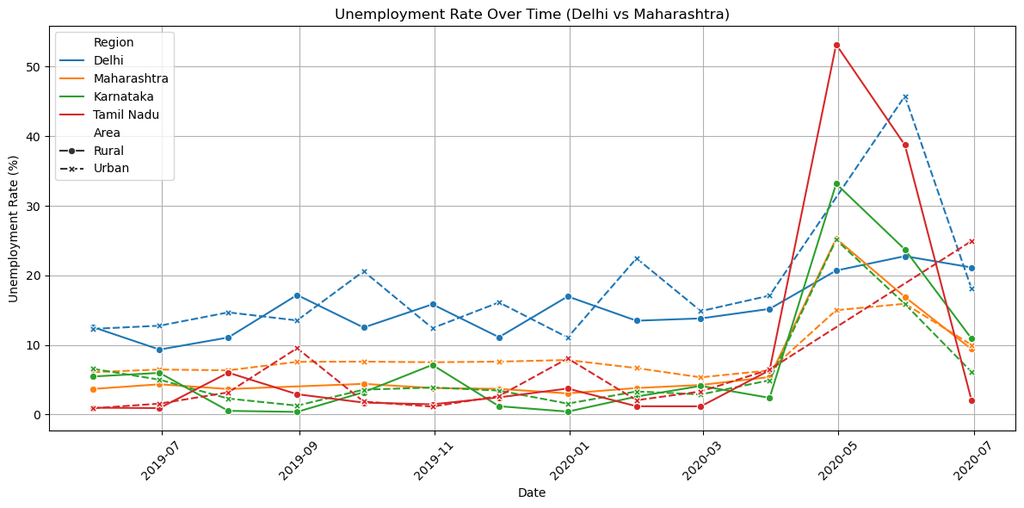

```python
plt.figure(figsize=(12, 6))
sns.lineplot(data=df_selected,
             x='Date',
             y='Estimated Unemployment Rate (%)',
             hue='Region',
             style='Area',  # Optional: distinguish Rural vs Urban
             markers=True)

plt.title('Unemployment Rate Over Time (Delhi vs Maharashtra)')
plt.xlabel('Date')
plt.ylabel('Unemployment Rate (%)')
plt.xticks(rotation=45)
plt.tight_layout()
plt.grid(True)
plt.show()
```

This plot visualizes the unemployment rates across different regions (Delhi, Maharashtra, Karnataka, Tamil Nadu) and areas (Rural, Urban) over a period from mid-2019 to mid-2020.

### Further Considerations:

- **Granularity of Data:** The plot provides monthly or bi-monthly data points, which is useful for observing trends.
- **Missing Context:** To gain deeper insights, it would be beneficial to correlate these unemployment figures with government policies, economic packages, and industry-specific impacts during the same period.

### Step 36: Calculate Average Unemployment Rate by Region and Area

#### Task Performed by This Code

This code calculates the **mean (average)** of the estimated unemployment rate for each combination of `Region` and `Area` (Rural or Urban).

The result is saved in a new DataFrame called `rural_urban_avg`.

#### Why It Is Used

- To **compare unemployment levels** across Rural and Urban areas within each state
- To support **comparative analysis** or plotting bar charts
- Useful for identifying whether unemployment is generally higher in Urban or Rural settings in different states

#### Theory

- `groupby()` is used to group the data by one or more categorical variables
- `.mean()` computes the average of the numerical column within each group
- `.reset_index()` converts the grouped result back to a regular DataFrame format

#### Line-by-Line Explanation

```python rural_urban_avg = df.groupby(['Region', 'Area'])['Estimated Unemployment Rate (%)'].mean().reset_index()

```python
rural_urban_avg = df.groupby(['Region', 'Area'])['Estimated Unemployment Rate (%)'].mean().reset_index()
```

### Step 37: Pivot the Average Unemployment Table for Rural–Urban Comparison

#### Task Performed by This Code

This code **reshapes** the `rural_urban_avg` DataFrame into a pivot table where:

- Each row is a `Region`
- Columns represent `Rural` and `Urban`
- Values are the **average unemployment rates**

It then **removes rows** where data for either `Rural` or `Urban` is missing.

#### Why It Is Used

- To enable **side-by-side comparison** of Rural vs Urban unemployment rates per state
- To prepare the data for computing **gaps** or plotting grouped bar charts
- Ensures we only analyze states that have **both Rural and Urban data**

#### Theory

- `pivot()` is used to transform a DataFrame from long to wide format
- `dropna()` removes any rows that have missing values (i.e., states with only one area type)

#### Line-by-Line Explanation

```python pivot_avg = rural_urban_avg.pivot(index='Region', columns='Area', values='Estimated Unemployment Rate (%)')

```python
pivot_avg = rural_urban_avg.pivot(index='Region', columns='Area', values='Estimated Unemployment Rate (%)')
pivot_avg = pivot_avg.dropna()  # Drop states with only Rural or Urban
```

### Step 38: Grouped Bar Plot – Rural vs Urban Unemployment Rate by Region

#### Task Performed by This Code

This code creates a **grouped bar chart** to compare the **average unemployment rate** in **Rural vs Urban** areas across each state using the `pivot_avg` DataFrame.

#### Why It Is Used

- To visually compare **area-wise unemployment** in each region
- Helps identify states where either **Rural or Urban areas are more affected**
- Easier to interpret than raw numbers or tables

#### Theory

- `DataFrame.plot(kind='bar')` creates a grouped bar chart for wide-form data
- Each group (bar cluster) represents a state (Region)
- Bars within each group represent `Rural` and `Urban` unemployment rates
- `matplotlib.pyplot` is used to customize the plot: title, labels, legend, etc.

#### Line-by-Line Explanation

```python pivot_avg.plot(kind='bar', figsize=(14, 6), rot=90, colormap='viridis')

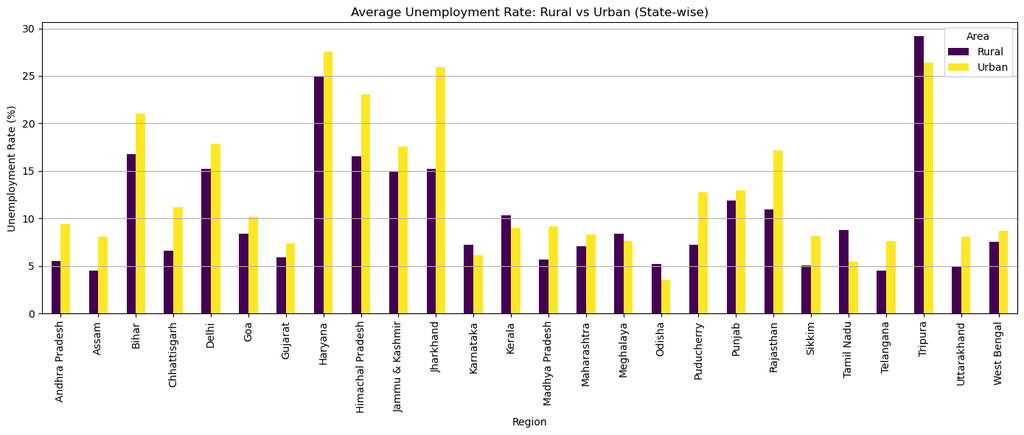

```python
pivot_avg.plot(kind='bar',
               figsize=(14, 6),
               rot=90,
               colormap='viridis')  # or any other colormap you like

plt.title('Average Unemployment Rate: Rural vs Urban (State-wise)')
plt.xlabel('Region')
plt.ylabel('Unemployment Rate (%)')
plt.grid(axis='y')
plt.legend(title='Area')
plt.tight_layout()
plt.show()
```

## Insights from Average Unemployment Rate: Rural vs Urban (State-wise)

This bar chart presents the average unemployment rate for various Indian states/union territories, disaggregated by rural and urban areas. It allows for a comparative analysis of employment trends across different regions and types of areas.

### Implications:

- The data highlights the heterogeneous nature of India's labor market. Policies aimed at employment generation need to be state-specific and consider the rural-urban divide.
- The higher urban unemployment rates in many states could indicate issues with skill matching, formal sector job creation, or rural-to-urban migration pressures.
- States with consistently low unemployment rates could serve as case studies for best practices in employment generation and economic stability.

This chart provides a valuable snapshot for understanding regional disparities and the differential impact of employment challenges in rural versus urban settings across India.

### Step 39: Prepare Heatmap Data – Average Unemployment Rate by Region and Year

#### Task Performed by This Code

This code calculates the **average estimated unemployment rate** for each combination of `Region` (state) and `Year`.  
It stores the result in a new DataFrame called `unemp_heatmap_data`.

#### Why It Is Used

- To prepare data for creating a **heatmap** (matrix-style chart)
- Helps **visually analyze trends** in unemployment across different years and states
- Useful for detecting **high or low unemployment periods** and regional shifts over time

#### Theory

- `groupby()` is used to group the dataset by two categorical columns: `Region` and `Year`
- `.mean()` calculates the average unemployment rate within each group
- `.reset_index()` flattens the grouped result into a DataFrame

#### Line-by-Line Explanation

```python unemp_heatmap_data = df.groupby(['Region', 'Year'])['Estimated Unemployment Rate (%)'].mean().reset_index()

```python
unemp_heatmap_data = df.groupby(['Region', 'Year'])['Estimated Unemployment Rate (%)'].mean().reset_index()
```

### Step 40: Pivot Unemployment Data for Heatmap (Region × Year Matrix)

#### Task Performed by This Code

This code reshapes the `unemp_heatmap_data` DataFrame into a **matrix format** where:

- Each row is a `Region` (state)
- Each column is a `Year`
- Each cell shows the **average unemployment rate** for that region in that year

This structure is saved as `heatmap_matrix`.

#### Why It Is Used

- To create a **heatmap** visualization
- Helps us identify which states and years had **high or low unemployment**
- Makes it easy to **compare trends across time and location**

#### Theory

- `pivot()` reshapes the DataFrame from **long format** to **wide format**:
  - `index` becomes the rows
  - `columns` become the column headers
  - `values` become the cell values

This structure is ideal input for functions like `seaborn.heatmap()`.

#### Line-by-Line Explanation

```python heatmap_matrix = unemp_heatmap_data.pivot( index='Region', columns='Year', values='Estimated Unemployment Rate (%)' )

```python
heatmap_matrix = unemp_heatmap_data.pivot(index='Region', columns='Year', values='Estimated Unemployment Rate (%)')
```

### Step 41: Heatmap – Visualizing Average Unemployment Rate by Region and Year

#### Task Performed by This Code

This code creates a **heatmap** to visually display the **average unemployment rate** for each state (`Region`) across multiple years using the `heatmap_matrix`.

#### Why It Is Used

- To **identify trends and patterns** in unemployment across regions and time
- Colors make it easy to **spot high or low values**
- Helps in **comparative analysis** between states and years

#### Theory

- A **heatmap** is a grid where each cell’s **color intensity** represents a value
- `seaborn.heatmap()` function takes a 2D matrix and visualizes it using color gradients
- Annotating values helps you see both the number and the trend at the same time

#### Line-by-Line Explanation

```python plt.figure(figsize=(3, 6))

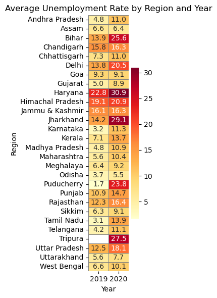

```python
plt.figure(figsize=(3,6))

sns.heatmap(heatmap_matrix,
            annot=True,  # shows unemployment rate numbers
            fmt=".1f",
            cmap="YlOrRd",  # yellow-orange-red color scale
            linewidths=0.5,
            linecolor='gray')

plt.title('Average Unemployment Rate by Region and Year')
plt.xlabel('Year')
plt.ylabel('Region')
plt.tight_layout()
plt.show()
```

## Insights from Average Unemployment Rate by Region and Year

This heatmap provides a clear comparison of average unemployment rates across various Indian states/union territories for two distinct years: 2019 and 2020. The color intensity helps quickly identify regions with higher (darker red) or lower (lighter yellow/orange) unemployment rates.

### Step 42: Boxplot – Labour Participation Rate Distribution Across Regions

#### Task Performed by This Code

This code creates a **boxplot** to visualize how the **Estimated Labour Participation Rate (%)** varies **across different states (Regions)**.

#### Why It Is Used

- To **compare distributions** of participation rates across states
- Helps identify:
  - **Median** values
  - **Variability** within each state
  - **Outliers** (very high/low rates)
- Useful for analyzing **regional workforce engagement trends**

#### Theory

- A **boxplot** (box-and-whisker plot) summarizes the distribution of data using:
  - **Box**: 25th to 75th percentile (IQR)
  - **Line inside the box**: Median (50th percentile)
  - **Whiskers**: Range excluding outliers
  - **Dots**: Outliers beyond 1.5×IQR from Q1 or Q3
- `seaborn.boxplot()` draws multiple boxplots grouped by a categorical variable (`Region`)

#### Line-by-Line Explanation

```python plt.figure(figsize=(16, 8))

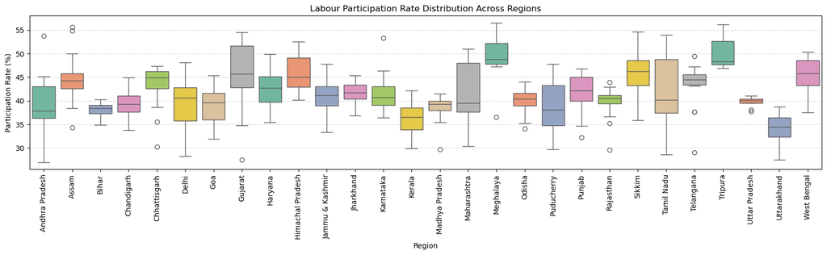

```python
plt.figure(figsize=(16, 5))

sns.boxplot(data=df,
            x='Region',
            y='Estimated Labour Participation Rate (%)',
            palette='Set2')

plt.title('Labour Participation Rate Distribution Across Regions')
plt.xlabel('Region')
plt.ylabel('Participation Rate (%)')
plt.xticks(rotation=90)
plt.grid(axis='y', linestyle='--', alpha=0.5)

plt.tight_layout()
plt.show()
```

## Insights from Labour Participation Rate Distribution Across Regions

This box plot illustrates the distribution of the Labour Participation Rate (LPR) across various Indian states and union territories. Each box represents the interquartile range (IQR), the line inside is the median, and the "whiskers" extend to data points within 1.5 times the IQR. Circles indicate outliers.

### Implications:

- **Economic Development:** Higher LPR generally indicates a more active and engaged workforce, which is crucial for economic growth. Regions with low LPR may face challenges related to underemployment, disguised unemployment, or large numbers of discouraged workers.
- **Policy Formulation:** Understanding these regional disparities is vital for policymakers to design targeted interventions. For regions with low LPR, strategies might focus on skill development, creating employment opportunities, and addressing social barriers to participation. For regions with high LPR, the focus might shift to improving the quality of employment and ensuring fair wages.
- **Demographic Factors:** LPR is influenced by demographics (age structure, gender), education levels, social norms, and the availability of suitable employment opportunities. Further analysis correlating LPR with these factors would provide deeper insights.

This plot provides a valuable overview of the variations in labor force engagement across India, highlighting both strengths and areas needing attention in different regions.

# Time series of employment and participation ratesm

### Step 43: Convert `Date` Column to Datetime Format

#### Task Performed by This Code

This code converts the `'Date'` column in the DataFrame `df` from string/object type to pandas `datetime` format.

#### Why It Is Used

- To enable **date-based operations** such as sorting, filtering, or extracting components (year, month, day)
- Necessary for accurate **time-series analysis** and plotting
- Many pandas functions work efficiently only if the column is in datetime format

#### Theory

- `pd.to_datetime()` converts a column or series of strings to pandas datetime objects
- Datetime objects allow access to `.dt` accessor for date components
- Proper datetime format supports sorting and resampling by date

#### Line-by-Line Explanation

```python df['Date'] = pd.to_datetime(df['Date'])

```python
df['Date'] = pd.to_datetime(df['Date'])
```

### Step 44: Sort DataFrame by Date

#### Task Performed by This Code

This code sorts the entire DataFrame `df` in ascending order based on the values in the `'Date'` column.

#### Why It Is Used

- Sorting by date ensures that data is in **chronological order**
- Important for **time series analysis, plotting, and trend detection**
- Many time-based operations (rolling averages, shifts) require sorted data for correctness

#### Theory

- `sort_values()` is a pandas method to sort DataFrame rows by one or more columns
- Sorting by date arranges records from the earliest to the latest

#### Line-by-Line Explanation

```python df = df.sort_values('Date')

```python
df = df.sort_values('Date')
```

### Step 45: Aggregate Average Employment and Labour Participation Rate by Date

#### Task Performed by This Code

This code groups the dataset by each unique `Date` and calculates the **average** of two columns:

- `Estimated Employed`
- `Estimated Labour Participation Rate (%)`

The result is saved into a new DataFrame called `trend_data`.

#### Why It Is Used

- To **summarize daily/monthly trends** across all regions combined
- Useful for analyzing **overall national employment and participation trends** over time
- Prepares data for time-series visualization

#### Theory

- `groupby('Date')`: Groups data by unique dates
- `[['col1', 'col2']].mean()`: Computes mean for specified columns within each group
- `.reset_index()`: Converts grouped data back to a DataFrame with `Date` as a column

#### Line-by-Line Explanation

```python trend_data = df.groupby('Date')[ ['Estimated Employed', 'Estimated Labour Participation Rate (%)'] ].mean().reset_index()

```python
trend_data = df.groupby('Date')[[
    'Estimated Employed',
    'Estimated Labour Participation Rate (%)'
]].mean().reset_index()
```

### Step 46: Time-Series Plot – Employment and Labour Participation Rate Trends

#### Task Performed by This Code

This code creates a **line plot** that shows two key trends over time:

- **Estimated Employed** (scaled to crores for easier reading)
- **Estimated Labour Participation Rate (%)**

#### Why It Is Used

- To visualize how employment numbers and labour participation rates change over time
- Helps detect patterns, increases, or declines in workforce engagement and employment
- Combining both metrics on the same plot enables easy comparison

#### Theory

- `plt.plot()` plots continuous data points connected by lines
- Plotting two series with different units on the same plot requires scaling or careful labeling
- Adding grid lines improves readability
- Legends clarify which line represents which metric

#### Line-by-Line Explanation

```python plt.figure(figsize=(14, 6))

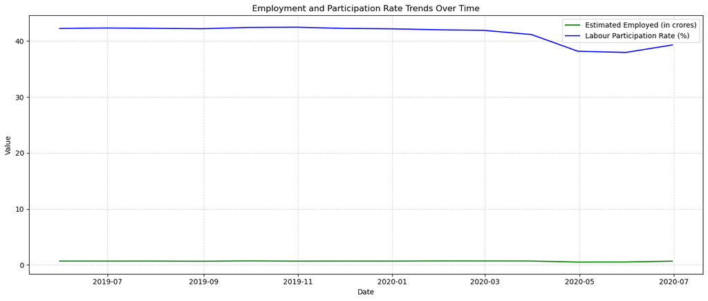

```python
plt.figure(figsize=(14, 6))

# Employment
plt.plot(trend_data['Date'], trend_data['Estimated Employed'] / 1e7, label='Estimated Employed (in crores)', color='green')

# Participation Rate
plt.plot(trend_data['Date'], trend_data['Estimated Labour Participation Rate (%)'], label='Labour Participation Rate (%)', color='blue')

plt.title('Employment and Participation Rate Trends Over Time')
plt.xlabel('Date')
plt.ylabel('Value')
plt.legend()
plt.grid(True, linestyle='--', alpha=0.5)
plt.tight_layout()
plt.show()
```

## Insights from Employment and Participation Rate Trends Over Time

This line plot visualizes the trends in 'Estimated Employed (in crores)' and 'Labour Participation Rate (%)' from mid-2019 to mid-2020. It offers a macroeconomic view of the labor market dynamics over this crucial period.

### Implications:

- **Vulnerability of the Labor Market:** The swift and significant drop in LPR and employment highlights the vulnerability of the labor market to large-scale disruptions like a pandemic.
- **Economic Shock:** The data clearly illustrates the immediate and profound economic shock caused by the COVID-19 induced lockdowns, leading to a substantial number of people exiting the labor force or losing jobs.
- **Phased Recovery:** The gradual increase in both metrics post-May 2020 points to a phased recovery, but it's important to note that by July 2020, neither had fully returned to pre-pandemic levels.
- **Policy Relevance:** This trend data is crucial for policymakers to assess the effectiveness of economic stimulus measures and to plan for long-term recovery strategies to restore labor force participation and employment to pre-crisis levels and beyond.

In summary, the plot vividly captures the severe contraction in India's labor market during the initial phase of the COVID-19 pandemic and the subsequent, albeit incomplete, recovery.

### Step 47: Calculate Basic Statistics of Estimated Unemployment Rate

#### Task Performed by This Code

This code computes **summary statistics** for the `'Estimated Unemployment Rate (%)'` column in the dataset `df`.  
Specifically, it calculates the **mean**, **median**, and **standard deviation**.

#### Why It Is Used

- To get a **quick overview** of the unemployment rate distribution
- Helps understand:
  - The **average unemployment rate** (`mean`)
  - The **middle value** in the data (`median`)
  - The **variability or spread** of unemployment rates (`std`)
- Useful for reporting and initial data exploration

#### Theory

- `agg()` function applies multiple aggregation operations to a pandas Series
- **Mean**: Sum of values divided by count
- **Median**: Middle value when data is sorted
- **Standard deviation (std)**: Measure of data spread around the mean

#### Line-by-Line Explanation

```python unemployment_stats = df['Estimated Unemployment Rate (%)'].agg(['mean', 'median', 'std'])

```python
unemployment_stats = df['Estimated Unemployment Rate (%)'].agg(['mean', 'median', 'std'])
print(" Unemployment Rate Statistics:")
print(unemployment_stats)
```

```
 Unemployment Rate Statistics:
mean      11.450937
median     8.160000
std       10.517371
Name: Estimated Unemployment Rate (%), dtype: float64
```

# Unemployment Rate Statistics

| Statistic | Value |
| --- | --- |
| Mean | 11.45% |
| Median | 8.16% |
| Std Dev | 10.52% |

### Key Insights:

- **Mean (Average):**
  - The average unemployment rate across the dataset is **11.45%**.
- **Median:**
  - The median unemployment rate is **8.16%**, which is **lower than the mean**, indicating a **right-skewed distribution** (some states or periods may have very high unemployment rates).
- **Standard Deviation:**
  - A high standard deviation of **10.52%** suggests **significant variation** in unemployment rates across different regions or time periods.

### Interpretation:

- The data shows **high inequality** in unemployment rates — some regions may have extremely high values (pulling the mean up), while the majority lie closer to the median.

### Step 48: Calculate Basic Statistics of Labour Participation Rate

#### Task Performed by This Code

This code calculates **summary statistics** for the `'Estimated Labour Participation Rate (%)'` column, including:

- **Mean** (average)
- **Median** (middle value)
- **Standard deviation** (spread)

#### Why It Is Used

- To understand the overall distribution of labour participation rates
- Helps identify typical values and variability in workforce participation
- Useful for data exploration and reporting

#### Theory

- `agg()` applies multiple aggregation functions on a pandas Series
- Mean, median, and standard deviation provide insights into data central tendency and dispersion

#### Line-by-Line Explanation

```python participation_stats = df['Estimated Labour Participation Rate (%)'].agg(['mean', 'median', 'std'])

```python
participation_stats = df['Estimated Labour Participation Rate (%)'].agg(['mean', 'median', 'std'])
print("\n Labour Participation Rate Statistics:")
print(participation_stats)
```

```
 Labour Participation Rate Statistics:
mean      41.393776
median    40.880000
std        5.238382
Name: Estimated Labour Participation Rate (%), dtype: float64
```

# Labour Participation Rate Statistics

| Statistic | Value |
| --- | --- |
| Mean | 41.39% |
| Median | 40.88% |
| Std Dev | 5.24% |

### Key Insights:

- **Mean (Average):**
  - The average labour participation rate is **41.39%**, meaning roughly 4 out of 10 people are participating in the labor force.
- **Median:**
  - The median value is **40.88%**, very close to the mean, suggesting a **fairly symmetric distribution**.
- **Standard Deviation:**
  - The standard deviation is **5.24%**, indicating **moderate variation** in participation rates across regions or time periods.

## What is Coefficient of Variation (CV)?

**Formula:**

$$ \text{CV} = \frac{\text{Standard Deviation}}{\text{Mean}} $$

The **coefficient of variation (CV)** shows how spread out the data is relative to the average.

It’s useful when comparing **variability across different regions** or **variables with different scales**.

### Step 49: Calculate Regional Statistics and Coefficient of Variation (CV)

#### Task Performed by This Code

This code groups the data by `Region` and calculates:

- Mean and standard deviation (`std`) of:
  - Estimated Unemployment Rate (%)
  - Estimated Labour Participation Rate (%)
- Then calculates the **Coefficient of Variation (CV)** for each metric per region.

#### Why It Is Used

- To understand how unemployment and participation rates **vary across states**
- Mean gives the average level for each region
- Standard deviation shows the variability/spread within the region
- CV (std/mean) is a **normalized measure of variability** allowing comparison of variability independent of magnitude
- Helps identify regions with **high volatility** or instability in unemployment or participation

#### Theory

- **GroupBy** aggregates data by a categorical variable (`Region`)
- **Coefficient of Variation (CV)** = Standard Deviation / Mean
  - Useful when comparing variability across datasets with different means

#### Line-by-Line Explanation

```python region_stats = df.groupby('Region')[[ 'Estimated Unemployment Rate (%)', 'Estimated Labour Participation Rate (%)' ]].agg(['mean', 'std'])

```python
# Group by Region
region_stats = df.groupby('Region')[[
    'Estimated Unemployment Rate (%)',
    'Estimated Labour Participation Rate (%)'
]].agg(['mean', 'std'])

# Rename for easier handling
region_stats.columns = ['Unemp_Mean', 'Unemp_Std', 'Part_Mean', 'Part_Std']

# Calculate CV for both
region_stats['Unemp_CV'] = region_stats['Unemp_Std'] / region_stats['Unemp_Mean']
region_stats['Part_CV'] = region_stats['Part_Std'] / region_stats['Part_Mean']

# Display top rows
region_stats[['Unemp_CV', 'Part_CV']].sort_values(by='Unemp_CV', ascending=False)
```

| Region | Unemp_CV | Part_CV |
| --- | --- | --- |
| Puducherry | 2.359943 | 0.133842 |
| Tamil Nadu | 1.732182 | 0.175564 |
| Karnataka | 1.213814 | 0.081132 |
| Telangana | 1.131388 | 0.115279 |
| Madhya Pradesh | 1.047431 | 0.058433 |
| Andhra Pradesh | 0.916403 | 0.126819 |
| Jharkhand | 0.810044 | 0.054768 |
| Sikkim | 0.798723 | 0.114862 |
| Goa | 0.758686 | 0.097555 |
| Gujarat | 0.702596 | 0.140113 |
| Kerala | 0.702121 | 0.081958 |
| Odisha | 0.671641 | 0.059284 |
| Bihar | 0.667874 | 0.033609 |
| Maharashtra | 0.663062 | 0.142686 |
| Chhattisgarh | 0.623184 | 0.091395 |
| Punjab | 0.540146 | 0.092776 |
| Meghalaya | 0.532377 | 0.100165 |
| Uttarakhand | 0.516054 | 0.086363 |
| West Bengal | 0.475801 | 0.078128 |
| Assam | 0.466381 | 0.106206 |
| Himachal Pradesh | 0.444422 | 0.081453 |
| Tripura | 0.442995 | 0.078487 |
| Uttar Pradesh | 0.428290 | 0.023922 |
| Rajasthan | 0.422001 | 0.067383 |
| Delhi | 0.419373 | 0.134178 |
| Chandigarh | 0.344443 | 0.082107 |
| Jammu & Kashmir | 0.340136 | 0.090256 |
| Haryana | 0.296658 | 0.084424 |

# Coefficient of Variation (CV) Analysis

| Region | Unemployment CV (# Unemp_CV) | Participation CV (# Part_CV) |
| --- | --- | --- |
| Puducherry | 2.36 | 0.13 |
| Tamil Nadu | 1.73 | 0.18 |
| Karnataka | 1.22 | 0.08 |
| Telangana | 1.13 | 0.12 |
| Madhya Pradesh | 1.05 | 0.06 |
| Andhra Pradesh | 0.91 | 0.13 |
| Jharkhand | 0.81 | 0.05 |
| Sikkim | 0.80 | 0.11 |
| Goa | 0.76 | 0.10 |
| Gujarat | 0.70 | 0.14 |

### Interpretation:

- **Unemployment rates** are generally more volatile across regions than **labour participation rates**.
- **High CV values** suggest policy or seasonal factors may be causing fluctuation in employment conditions, especially in Puducherry and Tamil Nadu.

### Step 50: Regional Summary Statistics and Coefficient of Variation Calculation

#### Task Performed by This Code

This code performs the following steps:

- Groups the data by `Region` (states)
- Calculates **mean** and **standard deviation (std)** for:
  - Estimated Unemployment Rate (%)
  - Estimated Labour Participation Rate (%)
- Computes the **Coefficient of Variation (CV)** for both unemployment and participation rates per region
- Displays the regions sorted by unemployment CV in descending order

#### Why It Is Used

- To **summarize central tendency and variability** of unemployment and participation rates by state
- CV normalizes variability relative to the mean, enabling comparison across regions with different averages
- Identifies which states have the **most variable unemployment rates** (higher CV means more fluctuation relative to mean)

#### Theory

- **GroupBy** aggregates data by a categorical variable
- **Mean** provides the average value
- **Standard Deviation** measures spread or variability
- **Coefficient of Variation (CV)** = std / mean; useful for comparing relative variability

#### Line-by-Line Explanation

```python region_stats = df.groupby('Region')[[ 'Estimated Unemployment Rate (%)', 'Estimated Labour Participation Rate (%)' ]].agg(['mean', 'std'])

```python
# Group by Region and compute mean and std
region_stats = df.groupby('Region')[[
    'Estimated Unemployment Rate (%)',
    'Estimated Labour Participation Rate (%)'
]].agg(['mean', 'std'])

# Rename columns
region_stats.columns = ['Unemp_Mean', 'Unemp_Std', 'Part_Mean', 'Part_Std']

# Compute Coefficient of Variation
region_stats['Unemp_CV'] = region_stats['Unemp_Std'] / region_stats['Unemp_Mean']
region_stats['Part_CV'] = region_stats['Part_Std'] / region_stats['Part_Mean']

# View results sorted by Unemployment CV
region_stats[['Unemp_CV', 'Part_CV']].sort_values(by='Unemp_CV', ascending=False)
```

| Region | Unemp_CV | Part_CV |
| --- | --- | --- |
| Puducherry | 2.359943 | 0.133842 |
| Tamil Nadu | 1.732182 | 0.175564 |
| Karnataka | 1.213814 | 0.081132 |
| Telangana | 1.131388 | 0.115279 |
| Madhya Pradesh | 1.047431 | 0.058433 |
| Andhra Pradesh | 0.916403 | 0.126819 |
| Jharkhand | 0.810044 | 0.054768 |
| Sikkim | 0.798723 | 0.114862 |
| Goa | 0.758686 | 0.097555 |
| Gujarat | 0.702596 | 0.140113 |
| Kerala | 0.702121 | 0.081958 |
| Odisha | 0.671641 | 0.059284 |
| Bihar | 0.667874 | 0.033609 |
| Maharashtra | 0.663062 | 0.142686 |
| Chhattisgarh | 0.623184 | 0.091395 |
| Punjab | 0.540146 | 0.092776 |
| Meghalaya | 0.532377 | 0.100165 |
| Uttarakhand | 0.516054 | 0.086363 |
| West Bengal | 0.475801 | 0.078128 |
| Assam | 0.466381 | 0.106206 |
| Himachal Pradesh | 0.444422 | 0.081453 |
| Tripura | 0.442995 | 0.078487 |
| Uttar Pradesh | 0.428290 | 0.023922 |
| Rajasthan | 0.422001 | 0.067383 |
| Delhi | 0.419373 | 0.134178 |
| Chandigarh | 0.344443 | 0.082107 |
| Jammu & Kashmir | 0.340136 | 0.090256 |
| Haryana | 0.296658 | 0.084424 |